# Reproducible Research Coursera Class Peer Assessment 1

## Load required R packages and the dataset

```r
library(dplyr)
```

```r
library(ggplot2)
library(grid)
library(stats)

setwd("H:/Public/Coursera/Reproducible Research")
fileUrl <- "https://d396qusza40orc.cloudfront.net/repdata%2Fdata%2Factivity.zip"
download.file(fileUrl, destfile = "./courseproject2.zip")
unzip("courseproject2.zip")
AMDdata <- read.csv("activity.csv")
AMDdata$date <- as.POSIXct(AMDdata$date, format="%Y-%m-%d")
print("https://d396qusza40orc.cloudfront.net/repdata%2Fdata%2Factivity.zip")
```

[1] “https://d396qusza40orc.cloudfront.net/repdata%2Fdata%2Factivity.zip”

```r
summary(AMDdata)
```

```
 steps             date                        interval
```

Min. : 0.00 Min. :2012-10-01 00:00:00 Min. : 0.0  
1st Qu.: 0.00 1st Qu.:2012-10-16 00:00:00 1st Qu.: 588.8  
Median : 0.00 Median :2012-10-31 00:00:00 Median :1177.5  
Mean : 37.38 Mean :2012-10-31 00:25:34 Mean :1177.5  
3rd Qu.: 12.00 3rd Qu.:2012-11-15 00:00:00 3rd Qu.:1766.2  
Max. :806.00 Max. :2012-11-30 00:00:00 Max. :2355.0  
NA’s :2304

### Histogram of Number of Steps Activity Patterns

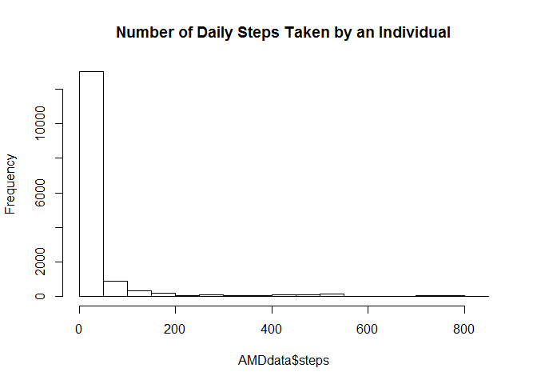

```r
hist(AMDdata$steps, main="Number of Daily Steps Taken by an Individual")
```

```r
### Summary Statistics on the Number of Steps Taken by an Individual per Day
print(paste("Mean Number of Steps = ", round(mean(AMDdata$steps, na.rm=T), digits=2)))
```

[1] “Mean Number of Steps = 37.38”

```r
print(paste("Median Number of Steps = ", median(AMDdata$steps, na.rm=T)))
```

[1] “Median Number of Steps = 0”

## Average Daily Activity Patterns: 5 Minute Intervals and Number of Steps

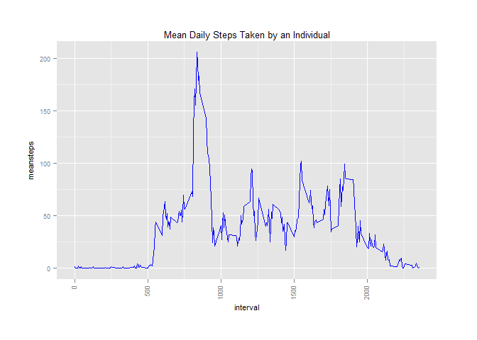

```r
meandata <- group_by(AMDdata, interval) %>% summarize(meansteps=mean(steps, na.rm=T)) %>% ungroup()
meandata$interval <- as.numeric(meandata$interval)
ggplot(data=meandata, aes(x=interval, y=meansteps)) +
    geom_line(color="blue") +
    theme(axis.text.x = element_text(angle = 90, vjust=0.25, hjust = 1), text =            element_text(size=8), axis.title.y=element_text(vjust=1), plot.margin = unit(c(1,1.5,1,1), "cm")) +
    ggtitle("Mean Daily Steps Taken by an Individual")
```

```r
meandata <- meandata[order(-meandata$meansteps), ]
print(paste("5 Minute Interval with Maximum Number of Steps identified:", meandata[1, 1]))
```

[1] “5 Minute Interval with Maximum Number of Steps identified: 835”

# Imputing missing values

```r
##Calcualting the Number of Missing Values
numNAs <- nrow(AMDdata) - nrow(na.omit(AMDdata))
print(paste("Number of Missing Values in the active dataset = ", numNAs))
```

[1] “Number of Missing Values in the active dataset = 2304”

```r
##Replacing Missing Values with the Daily Mean Number of Steps
AMDdataNA <- group_by(AMDdata, date) %>% mutate(meansteps=mean(steps, na.rm=T)) %>% ungroup()
AMDdataNA <- mutate(AMDdataNA, TotalMeanSteps=mean(steps, na.rm=T))
AMDdataNA <- mutate(AMDdataNA, steps_sub_NA = ifelse(is.na(steps) & is.na(meansteps), TotalMeanSteps, ifelse(is.na(steps) & !is.na(meansteps), meansteps, steps)))
```

### Histogram of Number of Steps Activity Patterns

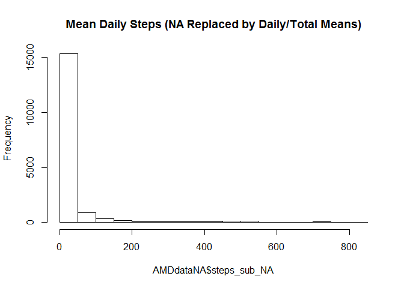

```r
hist(AMDdataNA$steps_sub_NA, main="Mean Daily Steps (NA Replaced by Daily/Total Means)")
```

```r
### Summary Statistics on the Number of Steps Taken by an Individual per Day
### Missing Values were Replaced with Total (no reported values in a day) or Daily Means (at least one reported value in a day)
print(paste("Mean Number of Steps = ", round(mean(AMDdataNA$steps_sub_NA, na.rm=T), digits=2)))
```

[1] “Mean Number of Steps = 37.38”

```r
print(paste("Median Number of Steps = ", round(median(AMDdataNA$steps_sub_NA, na.rm=T), digits=2)))
```

[1] “Median Number of Steps = 0”

# Comparison of Weekend and Weekday Steps

```r
##Assign Weekday or Weekend to Each Date
AMDdataNA <- mutate(AMDdataNA, weekdays = weekdays(date))
AMDdataNA <- mutate(AMDdataNA, workweekornot = ifelse(weekdays %in% c("Saturday", "Sunday"), "Weekend", "Weekday"))
AMDdataNA <- group_by(AMDdataNA, interval, weekdays) %>% mutate(steps_sub_NA_meanby_weekday = mean(steps_sub_NA, na.rm=T)) %>% ungroup()

summary(AMDdataNA)
```

```
 steps             date                        interval
```

Min. : 0.00 Min. :2012-10-01 00:00:00 Min. : 0.0  
1st Qu.: 0.00 1st Qu.:2012-10-16 00:00:00 1st Qu.: 588.8  
Median : 0.00 Median :2012-10-31 00:00:00 Median :1177.5  
Mean : 37.38 Mean :2012-10-31 00:25:34 Mean :1177.5  
3rd Qu.: 12.00 3rd Qu.:2012-11-15 00:00:00 3rd Qu.:1766.2  
Max. :806.00 Max. :2012-11-30 00:00:00 Max. :2355.0  
NA’s :2304  
meansteps TotalMeanSteps steps_sub_NA weekdays  
Min. : 0.1424 Min. :37.38 Min. : 0.00 Length:17568  
1st Qu.:30.6806 1st Qu.:37.38 1st Qu.: 0.00 Class :character  
Median :37.0920 Median :37.38 Median : 0.00 Mode :character  
Mean :37.3435 Mean :37.38 Mean : 37.38  
3rd Qu.:46.2969 3rd Qu.:37.38 3rd Qu.: 37.38  
Max. :73.5903 Max. :37.38 Max. :806.00  
NA’s :2592  
workweekornot steps_sub_NA_meanby_weekday Length:17568 Min. : 0.000  
Class :character 1st Qu.: 6.487  
Mode :character Median : 15.863  
Mean : 37.383  
3rd Qu.: 53.048  
Max. :263.863

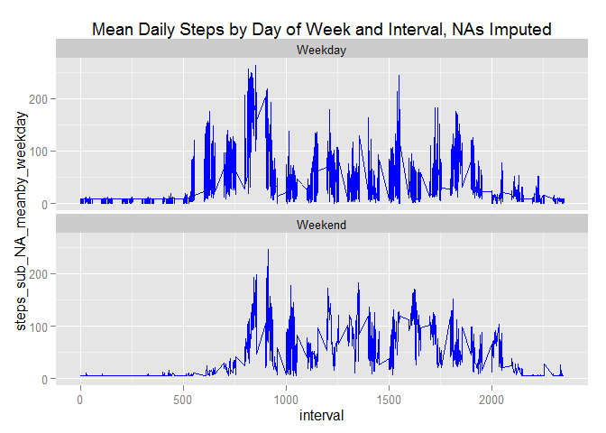

```r
##Chart Comparing Weekend and Weekday Steps
ggplot(data=AMDdataNA, aes(x=interval, y=steps_sub_NA_meanby_weekday)) +
  geom_line(color="blue") +
  facet_wrap(~workweekornot, ncol=1) +
  ggtitle("Mean Daily Steps by Day of Week and Interval, NAs Imputed")
```